# Remote Sensing | Free Full-Text | Carbon Stocks, Species Diversity and Their Spatial Relationships in the Yucatán Peninsula, Mexico | HTML

10.3390/rs13163179

[figure not shown]

Open AccessArticle

# Carbon Stocks, Species Diversity and Their Spatial Relationships in the Yucatán Peninsula, Mexico

by

José Luis Hernández-Stefanoni

<sup>1,*</sup>,

Miguel Ángel Castillo-Santiago

<sup>2</sup>,

Juan Andres-Mauricio

<sup>1</sup>,

Carlos A. Portillo-Quintero

<sup>3</sup>,

Fernando Tun-Dzul

<sup>1</sup> and

Juan Manuel Dupuy

<sup>1</sup>

<sup>1</sup>

Centro de Investigación Científica de Yucatán A.C., Unidad de Recursos Naturales, Calle 43 # 130, Colonia Chuburná de Hidalgo, Mérida CP 97200, Mexico

<sup>2</sup>

Laboratorio de Análisis de Información Geográfica y Estadística, El Colegio de la Frontera Sur, Carretera Panamericana y Periférico sur s/n., San Cristóbal de las Casas, Chiapas CP 29290, Mexico

<sup>3</sup>

Geospatial Technologies Laboratory, Department of Natural Resources Management, Texas Tech University, Box 42125, Lubbock, TX 79409-2125, USA

Author to whom correspondence should be addressed.

Academic Editor: Rasmus Fensholt

*Remote Sens.* **2021**, *13*(16), 3179; https://doi.org/10.3390/rs13163179

Received: 14 June 2021 / Revised: 5 August 2021 / Accepted: 9 August 2021 / Published: 11 August 2021

(This article belongs to the Special Issue [Novel Approaches in Tropical Forests Mapping and Monitoring – Time for Operationalization](https://www.mdpi.com/journal/remotesensing/special_issues/Tropical_Forests_Mapping))

## Abstract

Integrating information about the spatial distribution of carbon stocks and species diversity in tropical forests over large areas is fundamental for climate change mitigation and biodiversity conservation. In this study, spatial models showing the distribution of carbon stocks and the number of species were produced in order to identify areas that maximize carbon storage and biodiversity in the tropical forests of the Yucatan Peninsula, Mexico. We mapped carbon density and species richness of trees using L-band radar backscatter data as well as radar texture metrics, climatic and field data with the random forest regression algorithm. We reduced sources of errors in plot data of the national forest inventory by using correction factors to account for carbon stocks of small trees (<7.5 cm DBH) and for the temporal difference between field data collection and imagery acquisition. We created bivariate maps to assess the spatial relationship between carbon stocks and diversity. Model validation of the regional maps obtained herein using an independent data set of plots resulted in a coefficient of determination (R<sup>2</sup>) of 0.28 and 0.31 and a relative mean square error of 38.5% and 33.0% for aboveground biomass and species richness, respectively, at pixel level. Estimates of carbon density were influenced mostly by radar backscatter and climatic data, while those of species richness were influenced mostly by radar texture and climatic variables. Correlation between carbon density and species richness was positive in 79.3% of the peninsula, while bivariate maps showed that 39.6% of the area in the peninsula had high carbon stocks and species richness. Our results highlight the importance of combining carbon and diversity maps to identify areas that are critical—both for maintaining carbon stocks and for conserving biodiversity.

*Keywords:* biodiversity; [aboveground biomass](https://www.mdpi.com/search?q=aboveground%20biomass); [tropical dry forests](https://www.mdpi.com/search?q=tropical%20dry%20forests); [L-band SAR](https://www.mdpi.com/search?q=L-band%20SAR); [texture analysis](https://www.mdpi.com/search?q=texture%20analysis); [national forest inventory](https://www.mdpi.com/search?q=national%20forest%20inventory)

## 1. Introduction

Tropical forests are one of the most important reservoirs of carbon in the world, representing approximately 25% of the above and belowground terrestrial carbon stock [1]. In turn, tropical dry forests (TDF) represent more than 18% of the carbon stocks in the tropics [2] and are one of the most important tropical ecosystems, covering more than 40% of tropical forest regions in the world and 54% of the tropical forest in the Neotropics [3]. At the same time, tropical forests harbor more than 96% of all tree species estimated in all ecosystems worldwide [4]. TDF have lower levels of species diversity than humid tropical forests but have high levels of endemic plant species [5]. Unfortunately, deforestation is one of the greatest threats to these forests and is a significant source of greenhouse emissions aggravating global climate change [6]. Forest conversion also impacts plant diversity [7]. Therefore, integrating information about the spatial distribution of carbon stocks and plant species diversity of tropical forests over large areas is fundamental for climate change mitigation and biodiversity conservation.

Several studies have mapped the spatial distribution of carbon density, aboveground biomass (AGB) or species richness of plants at continental or global scales [8,9,10,11]. These maps have been elaborated with low spatial resolutions of 1 km or more. Other weaknesses of these studies have included a suboptimal number and distribution of sampling field plots over the area covered with remotely sensed data, as well as the use of field plots with different sizes, which make calibration and validation of the models more challenging [12,13]. Other studies have produced maps of carbon density or AGB at national or regional scales with finer spatial resolutions, close to 30 m [14,15]. These maps used mainly field data obtained from national forest inventories (NFI), which provide a more representative number of sampling plots as well as detailed information of vegetation structure used to estimate biomass [16]. In contrast, despite the current alarming loss of biodiversity, there is a lack of plant diversity maps with high spatial resolution at regional scales [17]. In this work, we created one of the first regional maps of tree species diversity with high spatial resolution (25 m) using the TDF of the Yucatan Peninsula as a model.

The Yucatan peninsula contains the second largest forest massif in the Americas (after the Amazon) and is dominated by different types of seasonal TDF with high levels of endemicity [18]. It is therefore important to estimate and map AGB or carbon density and plant diversity in this region. The TDFs of the Yucatan Peninsula comprise a large number of small-sized trees, which account for 15% to 40% of the biomass in mature TDFs and more than 80% of the biomass in young TDFs [19], and also contribute greatly to the species richness [20], especially in secondary forests [21]. However, the NFI in Mexico provides measurements only for trees with a diameter at breast height (DBH) above 7.5 cm [22]. Excluding small size trees from the NFI leads to a significant underestimation of AGB and species richness and requires the application of specific correction factors [23]. Additionally, the last Mexican NFI was conducted between 2009 and 2014; this six-year time interval resulted in temporal differences between field data collection and imagery acquisition, making it necessary to take into account changes in AGB due to growth, recruitment and mortality of trees. Using AGB as opposed to stand age functions obtained from chronosequence data can help to build predictive models of biomass changes over time that can be used to update field biomass estimates from NFI plots [23].

Studies estimating the spatial distribution of forest biomass and species richness through remotely sensed data have utilized different approaches and different remotely sensed data [24,25]. Biomass is generally influenced by vegetation structural attributes such as height of trees, stem diameter and basal area. Synthetic Aperture Radar (SAR) sensors are sensitive to forest structure, as backscatter signals are able to penetrate forest canopy. In particular, the Advanced Land Observing Satellite (ALOS) Phased Array L-band Synthetic Aperture Radar (PALSAR) from the Japanese Aerospace Exploration Agency (JAXA), with a wavelength of 23 cm, a pixel size of 25 m and full coverage over the world, provides data on forest structure that can be used to map carbon density or AGB at regional to global scales.

Variation in vegetation structure can also positively influence AGB; for example, leaf layering can improve light capturing, allowing plant communities to increase carbon storage [1]. Texture metrics of very high-resolution imagery have been successfully used to capture variation in the structure of tropical forests [26]. Even though the 25 m spatial resolution of ALOS-PALSAR imagery cannot discern individual trees or canopy openings, it can capture broader scales of variation, such as fragments with different successional age that differ in vegetation structure [27]. Thus, texture metrics from backscatter data can help to improve carbon density and AGB estimations while also allowing for reductions of the effects of saturation of radar backscatter signal [28].

Species diversity also increases with forest structure [17], but has been found to be strongly and positively associated with environmental or habitat heterogeneity [29], which is in turn associated with higher availability of niches [30]. There are different ways to measure environmental heterogeneity from remotely sensed data, from using variance of spectral data to more complex methods such as texture metrics, which reflect spatial variation within a moving window in an image [31]. Therefore, texture metrics derived from radar sensors can be used to estimate species diversity.

Additionally, at regional scales, several factors affect biomass and species richness including precipitation, soil fertility and time since disturbance. These factors are positively related to tropical tree species richness and forest biomass [32,33]. For seasonally dry forests, a measure of water deficit based on the difference between precipitation and evapotranspiration is particularly important as it affects rates of tree growth and recruitment [32]. Therefore, including water deficit may improve the accuracy of tree species richness and biomass maps in TDF.

Some studies have suggested a positive association between carbon density or AGB and species diversity. Forest biomass or carbon density has been used as a predictor of species richness, as plant diversity often shows a hump-shaped or saturating relationship with productivity [34]. Conversely, species diversity can foster biomass production through niche complementarity—that is, a more thorough and efficient use of resources by coexisting species due to a more complete occupation of available niches [35]. However, some studies have found weak or negative relationships between carbon density and species diversity [36]. The type of association between carbon density and diversity is of paramount importance, as areas that have both high carbon stocks and high levels of species diversity could provide climate change mitigation and biodiversity conservation at the same time. However, different strategies are required for areas of high diversity but low carbon stocks versus areas with low diversity and high carbon stocks.

Considering the importance of the relationship between carbon density and plant species diversity, the aims of this study were two-fold. First, we sought to improve the accuracy of regional maps of carbon density and tree species richness of the Yucatan peninsula by using L-band radar backscatter data, radar texture metrics, climatic and field data with the random forest regression algorithm. By accounting for carbon stocks and species richness of small trees, and for temporal differences between NFI field data collection and imagery acquisition, we expected to improve the accuracy of carbon density maps compared to previous studies. We also expected that the spatial distribution of carbon density would be more strongly related to radar backscatter (reflecting variation in forest structure), while species richness would be more strongly associated with texture metrics (reflecting structural heterogeneity). Second, we obtained bivariate maps of carbon density and tree species richness in order to evaluate the spatial relationships of these variables and to identify areas that maximize carbon storage and biodiversity in the tropical dry forests of Yucatan peninsula.

## 2. Materials and Methods

#### 2.1. Study Area

This study focused on the Yucatan peninsula, located in the southeast of Mexico (17°36′N–21°36′N, 86°43′W–92°26′W) (Figure 1B) and covering an area of 10.1 million hectares. The climate in the peninsula is tropical and warm, with a dry season lasting from November to April. The mean annual temperature ranges from 24 to 26 °C while mean annual precipitation ranges from 800 to 1300 mm/yr<sup>−1</sup>. The orography is basically flat with a few hills of low elevation in the south. Most of area in the peninsula is covered with tropical dry forests (TDF), including three main forest types distributed along an environmental gradient (Figure 1C). The northwest portion of the peninsula is the driest and is covered primarily by deciduous forest with a low canopy stature. Conversely, the southeast part of the peninsula is the most humid and is dominated by semi-evergreen forests with a taller canopy and a more complex vegetation structure. The middle portion of the peninsula has intermediate conditions and is dominated by semi-deciduous forest. Different stages of forest succession, including mature vegetation and secondary vegetation dominated by trees, shrubs or herbaceous plants, are present in all three types of TDF. The rest of the area in the peninsula is covered with other vegetation types such as mangrove forest or natural grasslands, with some trees and wetlands.

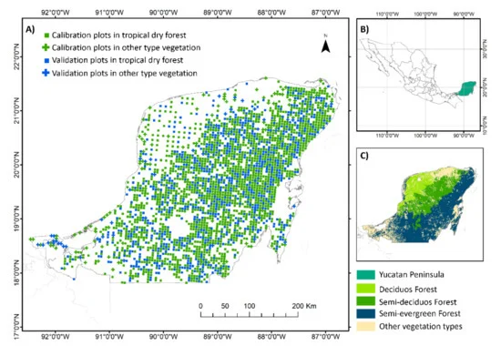

**Figure 1.** Location of the study area and field plots distribution: (**A**) the spatial distribution National Forest Inventory (NFI) field plots in the study area, (**B**) location of the Yucatan Peninsula, (**C**) distribution of the main vegetation types in the peninsula.

#### 2.2. Field Data and Calculations of Tree Species Richness and Aboveground Biomass

We used two independent data sets, one for calibrating and the other for validating the models of aboveground biomass (AGB) and tree diversity estimations. The data sets were obtained from the National Forest Inventory (NFI) of Mexico from surveys conducted between 2009 and 2014 (Figure 1A). We used 2847 plots distributed in the forested areas of the peninsula using regular grids of 5 × 5 km and 10 × 10 km depending on the vegetation type. Each field plot consisted of 4 circular 400 m<sup>2</sup> sub-plots distributed within an area of 1 ha. All trees with a diameter at breast height (DBH, 1.3 m) ≥ 7.5 cm were identified at species level and their diameters and heights were measured [22].

In each NFI plot, the number of woody plant species was computed. As the NFI does not sample trees with DBH < 7.5 cm, NFI plots were also corrected for species richness of small trees using correction factors calculated from field plots by vegetation type and richness category in a similar way to that for biomass [23].

#### 2.3. SAR Data Acquisition and Processing

We also obtained variability in backscatter values among pixels using the texture metrics of SAR imagery [47]. Texture metrics were used to examine if variability in pixel values, which can be used to characterize the vertical structure of canopies, could help to improve AGB estimations [48]. We also examined if backscatter variability could be used as a proxy for structural heterogeneity or variability of habitats for plant diversity estimations [29]. We computed eight second-order texture metrics (mean, variance, entropy, second angular momentum, dissimilarity, correlation, homogeneity and contrast), applying Gray Level Co-occurrence Matrix (GLMC) for the two backscatter polarizations (HH and HV), and for the NDBI index using the GLMC library of R software [49]. These texture metrics were calculated in four directions (0°, 45°, 90°, 135°) and averaged. Since the sampling plots covered an area of 1 ha, we used a window size of 3 × 3 pixels (0.56 ha), which is the closest to the sampling plot size. This process generated 24 variables, considering 8 texture metrics and three bands (HH, HV and NDBI) that were used for AGB and species richness estimations.

#### 2.4. Climate Data

The spatial distribution of biomass and species richness are affected by variations in temperature, precipitation and water availability—particularly in seasonally dry forests such as those of the Yucatan Peninsula where forests face climatic water deficits (CWD) during the dry season. Forest sites with lower water availability may have lower rates of growth and recruitment, which are related to low levels of AGB and species diversity [32,33]. Therefore, we used CWD data as an explanatory variable to evaluate if it could improve the accuracy of estimations of AGB and species richness.

We used a CWD map obtained from a previous study for the entire Yucatan Peninsula [23]. This map was generated using 425 climatic stations and the differences between raster data of precipitation and evapotranspiration during the dry months. This index measured the deficit of water in dry months and had negative values. In other words, forest sites that had an index value of zero did not suffer from water deficit. In contrast, forest sites with high water stress presented with negative values of the CWD index. The resolution of the CWD map was 125 m, and it was further resampled to 25 m.

#### 2.5. Model Development and Validation

A random forest regression model was used to estimate the spatial distribution of AGB and tree species richness from several explanatory variables obtained from backscatter and texture metrics derived from ALOS PALSAR and climatic data. One random forest regression model was constructed for each response variable (AGB and species richness). The model was obtained for all three tropical dry forests (deciduous, semi-deciduous and semi-evergreen) and for other vegetation types comprising mangrove forests and natural grasslands with some trees and wetlands. The models were fitted using the ModelMap library in R [50] using 70% of the plots for model calibration (1993 sampling units). The rest of the plots (30%) were used for model validation (854 sampling units). The plots used for validation were selected in the same proportion as calibration plots, considering the four vegetation classes (the tree types of tropical dry forest and a class for all other vegetation types). The validation plots were considered an independent dataset used for evaluating the accuracy of the estimated AGB and species richness.

#### 2.6. Generation of Carbon Density, Species Richness and Bivariate Maps

Maps of the spatial distribution of the response variables (carbon density and species richness), as well as their respective uncertainty maps, were generated. The species richness and carbon density maps were constructed using the random forest regression models obtained with the calibration dataset for all vegetation types (tropical dry forests and other vegetation types) and datasets of spatial predictors (HH, HV and NDBI, their texture metrics and the CWD). The maps were obtained with the “model.mapmake” function of the ModelMap library [50]. The uncertainty maps of species richness and AGB were built using the coefficient of variation (dividing the standard deviation by the mean). The random forest regression models computed the mean of all trees in the model for predicting each response variable, thereby allowing the calculation of standard deviations. Finally, the AGB map was converted to carbon density using a conversion factor of 0.516 [14].

A bivariate map that combined species richness and carbon density into a single map was created. The bivariate map of carbon density-species richness showed the number of species and the amount of carbon stock for each pixel in the study area. All three maps (carbon density, species richness and bivariate carbon density-species richness) used the Land Use Map from the Mexican National Institute of Statistics Geography and Information as a forest mask [51].

The mapped carbon density values for the entire Yucatan peninsula in this study were compared to previous studies that mapped carbon density or AGB in the same area [14,15]. The carbon density map of Cartus [14] was generated using canopy density estimates from Landsat, backscatter from ALOS-PALSAR and elevation derived from shuttle radar topography mission (STRM) as explanatory variables. Meanwhile, the AGB map obtained by Rodriguez–Veiga et al. [15] used vegetation indices derived from MODIS, backscatter from ALOS-PALSAR and elevation obtained from SRTM. Both studies used the NFI plots. However, they did not correct AGB values for small trees, or for temporal differences between field data collection and imagery acquisition. The comparison of the three AGB maps used the validation dataset described in Section 2.5 (854 plots) and the values of R<sup>2</sup>, RMSE, %RMSE and bias. In addition, we calculated the mean values and 95% confidence intervals of the differences between validation field plots and predicted AGB values of each map (Cartus et al. [14], Rodriguez–Veiga et al.) [15] and those obtained in this study) for different strata. The validation field data was stratified with AGB ranges every 50 Mg ha<sup>−1</sup>. We could not compare the tree species richness map since we could not find tree diversity maps of the Yucatan peninsula.

#### 2.7. Statistical Analyses

A variance partitioning analysis was performed to analyze how each group of explanatory variables (backscatter, texture metrics from radar and climate) contributed to explaining the variability of the response variables (AGB and species richness). This analysis allowed us to identify the unique contribution of each group of variables, as well as their combined contribution. The first group of variables (backscatter) included HH, HV and the NDBI index. The second group (texture) comprised all texture metrics calculated for HH, HV and the DNBI index. The third group was the CWD index.

The total explained variance (using the three sets of explanatory variables) was divided into three non-overlapping fractions—the percentage of variance explained exclusively by the backscatter, texture or CDW groups, respectively, as well as the variance explained jointly by all three groups of explanatory variables—using the method proposed by Borcard et al. [52].

Finally, we computed Pearson correlation coefficients between carbon density and species richness maps, as well as field data (with 2847 sampling plots), at two extensions: one for the entire peninsula and the other for areas inside of different ecosystems. First, we calculated the correlations over the entire Yucatan Peninsula using all pixels of the carbon density and species richness maps and field data. Then, we calculated separate correlations for the three main types of tropical dry forest and for the other vegetation types, as shown in Figure 1C. Next, we calculated correlation within different areas, including mature vegetation, secondary vegetation with trees, shrubs or herbaceous-dominated cover for the TDF, mangrove forest, natural grasslands with some trees and wetlands areas for other vegetation types. Finally, we calculated the mean correlation and a 95% confidence interval for deciduous forests, semi-deciduous forests, semi-evergreen forests and other vegetation types.

## 3. Results

#### 3.1. AGB and Species Richness Models Performance

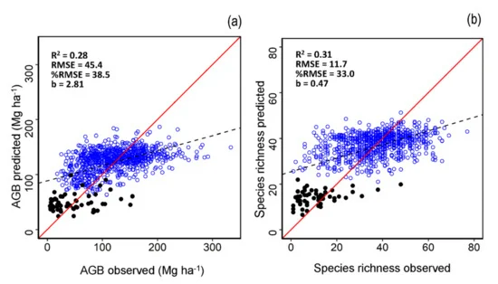

**Figure 2.** Comparison of observed versus predicted values for aboveground biomass (AGB) (**a**) and species richness of trees (**b**). Red lines are reference lines 1:1, while dashed lines are regression lines. The coefficient of determination (R<sup>2</sup>), the Root-Mean-Square Error (RMSE), the Percentage of Root-Mean-Square Error (%RMSE) and the bias were calculated using both vegetation classes (tropical dry forests and other vegetation types). Open blue circles represent forest plots, while filled black circles correspond to other vegetation-type plots.

#### 3.2. Regional Carbon Density, Species Richness and Bivariate Maps over the Yucatan Peninsula

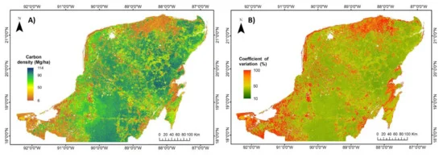

**Figure 3.** Estimated map of the aboveground carbon density for the entire Yucatan Peninsula (**A**) and the uncertainty map, measured with coefficient of variation (**B**).

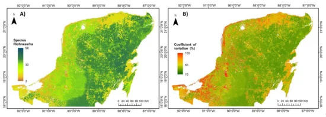

**Figure 4.** Estimated map of the species richness for the entire Yucatan Peninsula (**A**) and the uncertainty map measured with coefficient of variation (**B**).

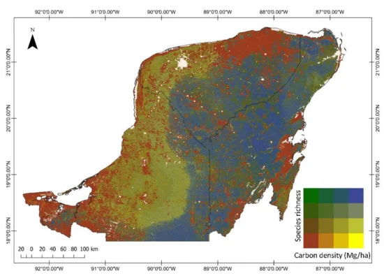

**Figure 5.** Map of the Yucatan Peninsula showing congruence between carbon density and species richness of trees. The hotspot areas that have high values for both carbon density and species richness are shown in blue.

#### 3.3. Comparison of the Aboveground Biomass Map with Previous Studies in the Yucatan Peninsula

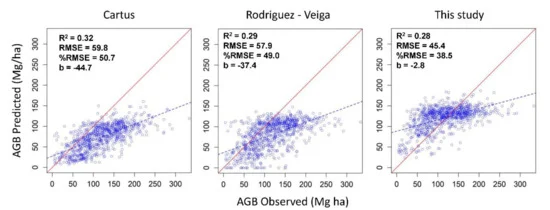

**Figure 6.** Observed versus predicted values for aboveground biomass in the maps generated in this study compared to the maps of Cartus el at. [14] and Rodriguez-Veiga et al. [15] for the Yucatan Peninsula. Red lines are reference lines 1:1, while dashed lines are regression lines.

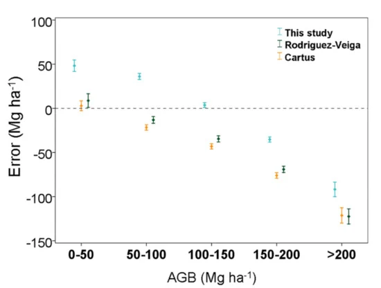

**Figure 7.** Mean values and 95% confidence intervals obtained as the differences between NFI field data plots used for validation and predicted AGB values of this study, and those of Cartus et al. [14] and Rodriguez-Veiga et al. [15] for different categorical AGB values.

#### 3.4. Importance of Variables to Estimate Carbon Density and Species Richness

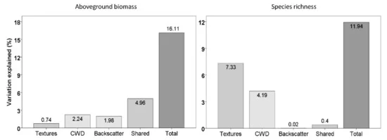

**Figure 8.** Variance partitioning analysis of the calibrated models to predict aboveground biomass and species richness from three groups of explanatory variables: (1) backscatter (HH, HV and NDBI index), (2) texture metrics from radar and (3) CWD (climatic water deficit).

#### 3.5. Relationships between Carbon Density and Species Richness

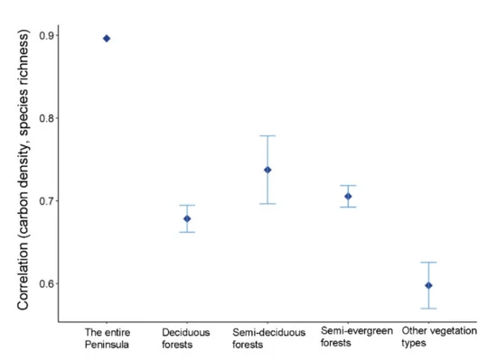

**Figure 9.** Correlation between carbon density and species richness for the entire peninsula and for different vegetation types: deciduous, semi-deciduous and semi-evergreen tropical dry forest forests and other vegetation types (mangrove forest, natural grasslands with some trees and wetlands). The diamonds represent the mean values and the lines 95% confidence intervals.

## 4. Discussion

#### 4.1. Evaluation of Carbon Density and Species Richness Maps

To improve the accuracy of carbon density and tree species richness of regional maps, we corrected the field-estimated values of carbon density and species richness by accounting for small-sized trees and for the temporal differences between field data collection and imagery acquisition. We also explored the relationships between carbon density and tree species richness, estimated in the field with radar backscatter, radar texture metrics and climatic data. We found that validation models showed a moderately accurate relationship and low errors between observed and predicted values of carbon density and tree species richness (R<sup>2</sup> = 0.28 and %RMSE = 38.5 and R<sup>2</sup> = 0.31 and %RMSE = 33.0, respectively). We also found similar spatial patterns for carbon density and tree species richness estimations in tropical dry forests. These results concurred with those reported by Xu et al. [53] which generated a map of carbon density in the Democratic Republic of Congo, one of the largest countries with tropical forests. Authors reported a RMSE of 105 Mg ha<sup>−1</sup> and an average of 280 Mg ha<sup>−1</sup> of AGB at pixel level, having a R<sup>2</sup> = 0.35 and %RMSE = 37.5. The relative error obtained for AGB in this study had similar or lower values compared with the accuracy assessment of regional AGB maps from other studies, which have reported relative RMSE from 37.0% to 67% at pixel level for Poland, Sweden and regions in Indonesia (Kalimantan), Mexico (Central Mexico and Yucatan peninsula), and South Africa (Eastern provinces) [24]. In a similar way, Su et al. [54] estimated AGB for China and reported a relative RMSE of 50.7% at pixel level. Meanwhile, Santoro et al. [55] estimated AGB globally at a 100 m resolution and reported a relative RMSE of 57.1% for tropical forest areas.

The representativeness of field data—that is, the amount and quality of information obtained from the NFI—was a key factor affecting the accuracy of our estimates of carbon density and species richness [24]. We therefore followed the methodology of Hernandez-Stefanoni et al. [23], who reported a reduction in relative errors of approximately 12% for AGB estimates when correcting NFI data for not including small-sized trees and for temporal differences between field and remotely sensed information. The regional uncertainty maps of carbon density and species richness showed the highest uncertainty values occurring in the other vegetation types (mangrove forests, natural grasslands with some trees and wetlands). In the same way, Figure 2 shows higher errors for estimating AGB and species richness for other vegetation types. The main reason for this high uncertainty is the low number of sample plots established for the other vegetation types class in the Mexican NFI [22], using a fixed grid of 10 × 10 km, compared to the grid of 5 × 5 km for tropical dry forest, and accounting for only 6.6% of the total number of plots in the Yucatan Peninsula (189 of 2847).

The accuracy of carbon density and species richness estimates could be significantly improved by increasing the number of sample field plots. Additional improvements in the accuracy of maps would be possible through the use of LiDAR plots with a two-stage upscaling method: first, relating field data with LiDAR metrics to map the variable of interest in areas covered by LiDAR, and then relating AGB (or species richness) estimated from LiDAR to satellite imagery and/or environmental information covering the entire area of interest. This approach has been applied successfully for estimating different vegetation attributes in several vegetation types [53,56]. Although there were some LiDAR data available for the Yucatan peninsula (collected by NASA’s G-LiHT airborne imager [57]) and the accuracy assessment of models relating AGB estimated in the field with LiDAR data revealed good performances (R<sup>2</sup> = 0.85 and %RMSE = 19.7 and R<sup>2</sup> = 0.85 and RMSE = 22.22 Mg ha<sup>−1</sup>, respectively, reported by Hernandez-Stefanoni et al. [23] and Urbazaev et al. [58]), the LiDAR data do not cover all the range of variability of biomass at field, so attempts to map AGB using the upscaling approach have been unsuccessful [23,58].

There are several maps of carbon density or AGB at the national scale in Mexico. The carbon density map of Cartus [14] reported, at a pixel level, an R<sup>2</sup> from 0.2 to 0.5 depending on vegetation type and a relative RMSE of 54.0% and 63.0% on flat and steep slopes areas respectably. While, the AGB map obtained by Rodriguez-Veiga et al. [15] reported, at a pixel level, an R<sup>2</sup> of 0.31 and a relative RMSE of 79.3%. These R<sup>2</sup> values were comparable with the 0.28 obtained in this study, but their relative RMSE values were higher than the 38.5% reported in this study, indicating a better performance of the AGB map obtained herein. On the other hand, we also presented the first regional map of tree species richness over the Yucatan Peninsula.

Finally, as we expected, carbon density was mostly associated with radar backscatter, while species richness was mostly related to radar texture metrics. The variance partitioning analysis indicated that the backscatter variables explained a larger percentage of variation in AGB (2.0%) compared to texture metrics (0.7%). Conversely, texture metrics had a higher influence on species richness (7.3%) compared to backscatter (0.02%). SAR sensors—such as ALOS PALSAR—with large wavelengths can easily penetrate the forest canopy, allowing accurate estimates of basal area, diameter and tree height, all which are related to biomass [63]. Meanwhile, texture metrics that measure spectral variability have been closely related to species richness [64], as these metrics are proxies of habitat heterogeneity. Greater heterogeneity of habitats allows the coexistence of a higher number of species [65].

#### 4.2. Associations between Carbon Density and Species Richness in the Yucatan Peninsula

Although carbon density and species richness of trees showed great variability across the Yucatan Peninsula, the overall correlation between both variables was high (r = 0.9, p < 0.0001), with 79.3% of the area showing a positive relationship, and only 20.7% a negative association. These results concurred with other studies that observed a positive association between these two variables in tropical forests distributed around the world [68] and in the Neotropics [32]. The results of this study also have practical implications for planning activities that simultaneously promote carbon maintenance and diversity conservation. However, this overall pattern hides some important differences among vegetation types. When we analyzed the association between carbon density and species richness by vegetation type, we found that those types with a lower spatial extent also showed lower correlations. Thus, the other vegetation types showed the lowest correlation (r = 0.6) and extent, followed by deciduous forest (r = 0.68), whereas the semi-deciduous and semi-evergreen forests, which had the largest spatial extent, had stronger correlations (r = 0.74 and r = 0.71, respectively). These patterns are likely observed because the association between carbon density (or species richness) and environmental variables is weaker when there is a comparatively small variability in environmental factors, such as that found in smaller spatial extents [69]. Finally, it is important to consider that the association between carbon density and species richness in this study was applied to trees. Other biological groups which are important components of biodiversity, including herbaceous plants, arthropods and soil (micro)organisms, should also be considered, as they may present different associations with forest carbon density.

## 5. Conclusions

In this study, we presented an improved carbon density map of forests across the Yucatan Peninsula with a pixel resolution of 25 m. We corrected field-estimated carbon density values from the Mexican national forest inventory, which allowed us to account for carbon stored in small-sized trees and for temporal differences between field data collection and imagery acquisition. This helped to reduce errors in estimating carbon density by 10.5% to 12.2%, compared to previous studies. In addition, the inclusion of texture metrics of L-band radar imagery, and the use of water deficits in the models, further contributed to reducing the estimation bias. This also reduced the saturation effects of radar imagery, since texture metrics can capture variations in the vegetation structures of forest fragments of different successional ages that differ in carbon density.

We also presented the first map of tree species richness over the Yucatan Peninsula with a spatial resolution of 25 m. This map followed the same approach as the carbon density map, relating tree species richness measured in the field with radar backscatter, texture metrics and climatic data using random forest regression models, as well as corrections of values from national forest inventory plots. The goodness of fit and relative RMSE of this map were similar to those of the carbon density map. As expected, the most important predictors of species richness were texture metrics of L-band radar backscatter, which measure spectral variability (used in this study as a proxy of habitat heterogeneity). By contrast, the backscatter of L-band radar, which relates closely with vegetation structure, was more important to explain variation in carbon density.

Finally, we mapped the spatial association between carbon density and species richness across the Yucatan Peninsula. We found a positive relationship in 79.3% of the study area, with 39.6% of the forests in the peninsula showing both high carbon densities and high species richness of trees. These forests are thus highly relevant for conserving biodiversity and, at the same time, averting climate change.

## Author Contributions

Conceptualization, J.L.H.-S.; methodology, J.A.-M., J.L.H.-S.; writing—original draft preparation, J.L.H.-S.; writing—review and editing, M.Á.C.-S., C.A.P.-Q., F.T.-D. and J.M.D. All authors have read and agreed to the published version of the manuscript.

## Funding

This research was funded by Ecometrica LTD and the United Kingdom Space Agency financed this research as part of the project Forests 2020.

## Data Availability Statement

The ALOS PALSAR data used in this study was obtained from (https://www.eorc.jaxa.jp/ALOS/en/top/obs_top.htm, accessed on 10 August 2021). Data from the National Forest Inventory can be obtained by request to CONAFOR (Comisión Nacional Forestal, https://www.gob.mx/conafor, accessed on 1 August 2021).

## Acknowledgments

We thank the Mexican National Forestry Commission (CONAFOR) for kindly providing forest inventory data.

## Conflicts of Interest

The authors declare no conflict of interest.

## References

1. Poorter, L.; van der Sande, M.T.; Thompson, J.; Arets, E.J.; Alarcón, A.; Álvarez-Sánchez, J.; Ascarrunz, N.; Balvanera, P.; Barajas-Guzmán, G.; Boit, A.; et al. Diversity enhances carbon storage in tropical forests. Glob. Ecol. Biogeogr. **2015**, 24, 1314–1328. [Google Scholar] [[CrossRef](https://doi.org/10.1111/geb.12364)]
2. Keith, H.; Mackey, B.G.; Lindenmayer, D.B. Re-evaluation of forest biomass carbon stocks and lessons from the world’s most carbon-dense forests. Proc. Natl. Acad. Sci. USA **2009**, 106, 11635–11640. [Google Scholar] [[CrossRef](https://doi.org/10.1073/pnas.0901970106)] [[PubMed](https://www.ncbi.nlm.nih.gov/pubmed/19553199)]
3. Portillo-Quintero, C.A.; Sánchez-Azofeifa, G.A. Extent and conservation of tropical dry forests in the Americas. Biol. Conserv. **2010**, 143, 144–155. [Google Scholar] [[CrossRef](https://doi.org/10.1016/j.biocon.2009.09.020)]
4. Fine, P.V.A.; Ree, R.H.; Burnham, R.J. The disparity in tree species richness among tropical, temperate, and boreal biomes: The geographical area and age hypothesis. In Tropical Forest Community Ecology; Carson, R.P., Schnitzer, S.A., Eds.; Blackwell: Oxford, UK, 2008; pp. 31–45. [Google Scholar]
5. Banda, K.; Delgado-Salinas, A.; Dexter, K.G.; Linares-Palomino, R.; Oliveira-Filho, A.; Prado, D.; Pullan, M.; Quintana, C.; Riina, R.; Rodríguez, G.M.; et al. Plant diversity patterns in neotropical dry forests and their conservation implications. Science **2016**, 353, 1383–1387. [Google Scholar] [[CrossRef](https://doi.org/10.1126/science.aaf5080)]
6. Friedlingstein, P.; Jones, M.W.; O’sullivan, M.; Andrew, R.M.; Hauck, J.; Peters, G.P.; Peters, W.; Pongratz, J.; Sitch, S.; Le Quéré, C.; et al. Global carbon budget 2019. Earth Syst. Sci. Data **2019**, 11, 1783–1838. [Google Scholar] [[CrossRef](https://doi.org/10.5194/essd-11-1783-2019)]
7. Watson, J.E.; Dudley, N.; Segan, D.B.; Hockings, M. The performance and potential of protected areas. Nature **2014**, 515, 67–73. [Google Scholar] [[CrossRef](https://doi.org/10.1038/nature13947)]
8. Saatchi, S.S.; Harris, N.L.; Brown, S.; Lefsky, M.; Mitchard, E.T.; Salas, W.; Zutta, B.R.; Buermann, W.; Lewis, S.L.; Hagen, S.; et al. Benchmark map of forest carbon stocks in tropical regions across three continents. Proc. Natl. Acad. Sci. USA **2011**, 108, 9899–9904. [Google Scholar] [[CrossRef](https://doi.org/10.1073/pnas.1019576108)]
9. Baccini, A.G.S.J.; Goetz, S.J.; Walker, W.S.; Laporte, N.T.; Sun, M.; Sulla-Menashe, D.; Hackler, J.; Beck, P.S.A.; Dubayah, R.; Friedl, M.A.; et al. Estimated carbon dioxide emissions from tropical deforestation improved by carbon-density maps. Nat. Clim. Chang. **2012**, 2, 182–185. [Google Scholar] [[CrossRef](https://doi.org/10.1038/nclimate1354)]
10. Kier, G.; Mutke, J.; Dinerstein, E.; Ricketts, T.H.; Küper, W.; Kreft, H.; Barthlott, W. Global patterns of plant diversity and floristic knowledge. J. Biogeogr. **2005**, 32, 1107–1116. [Google Scholar] [[CrossRef](https://doi.org/10.1111/j.1365-2699.2005.01272.x)]
11. Kreft, H.; Jetz, W. Global patterns and determinants of vascular plant diversity. Proc. Natl. Acad. Sci. USA **2007**, 104, 5925–5930. [Google Scholar] [[CrossRef](https://doi.org/10.1073/pnas.0608361104)] [[PubMed](https://www.ncbi.nlm.nih.gov/pubmed/17379667)]
12. Houghton, R.A.; Hall, F.; Goetz, S.J. Importance of biomass in the global carbon cycle. J. Geophys. Res. Biogeosci. **2009**, 114, 1–13. [Google Scholar] [[CrossRef](https://doi.org/10.1029/2009JG000935)]
13. Keil, P.; Chase, J.M. Global patterns and drivers of tree diversity integrated across a continuum of spatial grains. Nat. Ecol. Evol. **2019**, 3, 390–399. [Google Scholar] [[CrossRef](https://doi.org/10.1038/s41559-019-0799-0)]
14. Cartus, O.; Kellndorfer, J.; Walker, W.; Franco, C.; Bishop, J.; Santos, L.; Fuentes, J. A national, detailed map of forest aboveground carbon stocks in Mexico. Remote. Sens. **2014**, 6, 5559–5588. [Google Scholar] [[CrossRef](https://doi.org/10.3390/rs6065559)]
15. Rodríguez-Veiga, P.; Saatchi, S.; Tansey, K.; Balzter, H. Magnitude, spatial distribution and uncertainty of forest biomass stocks in Mexico. Remote. Sens. Environ. **2016**, 183, 265–281. [Google Scholar] [[CrossRef](https://doi.org/10.1016/j.rse.2016.06.004)]
16. Réjou-Méchain, M.; Barbier, N.; Couteron, P.; Ploton, P.; Vincent, G.; Herold, M.; Mermoz, S.; Saatchi, S.; Chave, J.; de Boissieu, F.; et al. Upscaling Forest biomass from field to satellite measurements: Sources of errors and ways to reduce them. Surv. Geophys. **2019**, 40, 881–911. [Google Scholar] [[CrossRef](https://doi.org/10.1007/s10712-019-09532-0)]
17. Marselis, S.M.; Abernethy, K.; Alonso, A.; Armston, J.; Baker, T.R.; Bastin, J.F.; Bogaert, J.; Boyd, D.S.; Boeckx, P.; Burslem, D.F.R.P.; et al. Evaluating the potential of full-waveform lidar for mapping pan-tropical tree species richness. Glob. Ecol. Biogeogr. **2020**, 29, 1799–1816. [Google Scholar] [[CrossRef](https://doi.org/10.1111/geb.13158)]
18. Dupuy, J.M.; Durán García, R.; García Contreras, G.; Arellano Morin, J.; Acosta Lugo, E.; Méndez González, M.E.; Andrade Hernandez, M. Chapter 8: Conservation and Use. In Biodiversity and Conservation of the Yuca-tán Peninsula; Islebe, G.A., Schmook, B., Calmé, S., León-Cortés, J.L., Eds.; Springer: Cham, Switzerland, 2015; pp. 1–5. [Google Scholar]
19. Read, L.; Lawrence, D. Recovery of biomass following shifting cultivation in dry tropical forests of the Yucatan. Ecol. Appl. **2003**, 13, 85–97. [Google Scholar] [CrossRef]
20. Fricker, G.A.; Wolf, J.A.; Saatchi, S.S.; Gillespie, T.W. Predicting spatial variations of tree species richness in trop-ical forests from high-resolution remote sensing. Ecol. Appl. **2015**, 25, 1776–1789. [Google Scholar] [[CrossRef](https://doi.org/10.1890/14-1593.1)] [[PubMed](https://www.ncbi.nlm.nih.gov/pubmed/26591445)]
21. Dupuy, J.M.; Hernández-Stefanoni, J.L.; Hernández-Juárez, R.A.; Tetetla-Rangel, E.; López-Martínez, J.O.; Leyequién-Abarca, E.; May-Pat, F. Patterns and correlates of tropical dry forest structure and composition in a highly replicated chronosequence in Yucatan, Mexico. Biotropica **2012**, 44, 151–162. [Google Scholar] [[CrossRef](https://doi.org/10.1111/j.1744-7429.2011.00783.x)]
22. CONAFOR. Inventario nacional forestal y de suelos. Inf. Result. **2018**, 1, 2009–2014. [[Google Scholar](https://scholar.google.com/scholar_lookup?title=Inventario+nacional+forestal+y+de+suelos&author=CONAFOR&publication_year=2018&journal=Inf.+Result.&volume=1&pages=2009%E2%80%932014)]
23. Hernández-Stefanoni, J.L.; Castillo-Santiago, M.Á.; Mas, J.F.; Wheeler, C.E.; Andres-Mauricio, J.; Tun-Dzul, F.; George-Chacón, S.P.; Reyes-Palomeque, G.; Castellanos-Basto, B.; Vaca, R.; et al. Improving aboveground biomass maps of tropical dry forests by integrating LiDAR, ALOS PALSAR, climate and field data. Carbon Balance Manag. **2020**, 15, 1–17. [Google Scholar] [[CrossRef](https://doi.org/10.1186/s13021-020-00151-6)] [[PubMed](https://www.ncbi.nlm.nih.gov/pubmed/32729000)]
24. Rodríguez-Veiga, P.; Quegan, S.; Carreiras, J.; Persson, H.J.; Fransson, J.E.; Hoscilo, A.; Ziółkowski, D.; Stereńczak, K.; Lohberger, S.; Stängel, M.; et al. Forest biomass retrieval approaches from earth observation in different biomes. Int. J. Appl. Earth Obs. Geoinf. **2019**, 77, 53–68. [Google Scholar] [[CrossRef](https://doi.org/10.1016/j.jag.2018.12.008)]
25. Wang, R.; Gamon, J.A. Remote sensing of terrestrial plant biodiversity. Remote. Sens. Environ. **2019**, 231, 111218. [Google Scholar] [[CrossRef](https://doi.org/10.1016/j.rse.2019.111218)]
26. Ploton, P.; Barbier, N.; Couteron, P.; Antin, C.M.; Ayyappan, N.; Balachandran, N.; Barathan, N.; Bastin, J.F.; Chuyong, G.; Dauby, G.; et al. Toward a general trop-ical forest biomass prediction model from very high resolution optical satellite images. Remote. Sens. Environ. **2017**, 200, 140–153. [Google Scholar] [[CrossRef](https://doi.org/10.1016/j.rse.2017.08.001)]
27. Thapa, R.B.; Watanabe, M.; Motohka, T.; Shimada, M. Potential of high-resolution ALOS–PALSAR mosaic texture for aboveground forest carbon tracking in tropical region. Remote. Sens. Environ. **2015**, 160, 122–133. [Google Scholar] [[CrossRef](https://doi.org/10.1016/j.rse.2015.01.007)]
28. Joshi, N.; Mitchard, E.T.; Brolly, M.; Schumacher, J.; Fernández-Landa, A.; Johannsen, V.K.; Marchamalo, M.; Fensholt, R. Understanding ‘saturation’of radar signals over forests. Sci. Rep. **2017**, 7, 1–11. [Google Scholar] [[CrossRef](https://doi.org/10.1038/s41598-017-03469-3)]
29. Rocchini, D.; Balkenhol, N.; Carter, G.A.; Foody, G.M.; Gillespie, T.W.; He, K.S.; Kark, S.; Levin, N.; Lucas, K.; Luoto, M.; et al. Remotely sensed spectral heterogeneity as a proxy of species diversity: Recent advances and open challenges. Ecol. Inform. **2010**, 5, 318–329. [Google Scholar] [[CrossRef](https://doi.org/10.1016/j.ecoinf.2010.06.001)]
30. Stein, A.; Gerstner, K.; Kreft, H. Environmental heterogeneity as a universal driver of species richness across taxa, biomes and spatial scales. Ecol. Lett. **2014**, 17, 866–880. [Google Scholar] [[CrossRef](https://doi.org/10.1111/ele.12277)] [[PubMed](https://www.ncbi.nlm.nih.gov/pubmed/24751205)]
31. George-Chacon, S.P.; Dupuy, J.M.; Peduzzi, A.; Hernandez-Stefanoni, J.L. Combining high resolution satellite imagery and lidar data to model woody species diversity of tropical dry forests. Ecol. Indic. **2019**, 101, 975–984. [Google Scholar] [[CrossRef](https://doi.org/10.1016/j.ecolind.2019.02.015)]
32. Poorter, L.; Bongers, F.; Aide, T.M.; Zambrano, A.M.A.; Balvanera, P.; Becknell, J.M.; Boukili, V.; Brancalion, P.H.S.; Broadbent, E.N.; Chazdon, R.L.; et al. Biomass resili-ence of Neotropical secondary forests. Nature (London) **2016**, 530, 211–214. [Google Scholar] [[CrossRef](https://doi.org/10.1038/nature16512)]
33. Rozendaal, D.M.A.; Bongers, F.; Aide, T.M.; Alvarez-Dávila, E.; Ascarrunz, N.; Balvanera, P.; Becknell, J.M.; Bentos, T.V.; Brancalion, P.H.S.; Cabral, G.A.L.; et al. Biodiversity recovery of Neotropical secondary forests. Sci. Adv. **2019**, 5, eaau3114. [Google Scholar] [[CrossRef](https://doi.org/10.1126/sciadv.aau3114)] [[PubMed](https://www.ncbi.nlm.nih.gov/pubmed/30854424)]
34. Mittelbach, G.G.; Steiner, C.F.; Scheiner, S.M.; Gross, K.L.; Reynolds, H.L.; Waide, R.B.; Willig, W.R.; Dodson, S.I.; Gough, L. What is the observed relationship between species richness and productivity? Ecology **2001**, 82, 2381–2396. [Google Scholar] [CrossRef]
35. Sullivan, M.J.; Talbot, J.; Lewis, S.L.; Phillips, O.L.; Qie, L.; Begne, S.K.; Chave, J.; Cuni-Sanchez, A.; Hubau, W.; Lopez-Gonzalez, G.; et al. Diversity and carbon storage across the tropical forest biome. Sci. Rep. **2017**, 7, 1–12. [Google Scholar] [[CrossRef](https://doi.org/10.1038/srep39102)]
36. Murray, J.P.; Grenyer, R.; Wunder, S.; Raes, N.; Jones, J.P. Spatial patterns of carbon, biodiversity, deforestation threat, and REDD+ projects in Indonesia. Conserv. Biol. **2005**, 29, 1434–1445. [Google Scholar] [[CrossRef](https://doi.org/10.1111/cobi.12500)]
37. Ramírez Ramírez, G.; Dupuy Rada, J.M.; Ramírez y Avilés, L.; Solorio Sánchez, F.J. Evaluación de ecuaciones alométricas de biomasa epigea en una selva mediana subcaducifolia de Yucatán. Madera bosques **2017**, 23, 163–179. [Google Scholar] [[CrossRef](https://doi.org/10.21829/myb.2017.2321452)]
38. Chave, J.; Andalo, C.; Brown, S.; Cairns, M.A.; Chambers, J.Q.; Eamus, D.; Fölster, H.; Fromard, F.; Higuchi, N.; Kira, T.; et al. Tree allometry and improved estimation of carbon stocks and balance in tropical forests. Oecologia **2005**, 145, 87–99. [Google Scholar] [[CrossRef](https://doi.org/10.1007/s00442-005-0100-x)]
39. Guyot, J. Estimation du Stock de Carbone dans la Végétation des Zones Humides de la Péninsule du Yucatan. Memoire de fin d’etudes. Licentiate Thesis, AgroParis Tech-El Colegio de la Frontera Sur, Chiapas, Mexico, 2011; p. 110. [Google Scholar]
40. Cairns, M.A.; Olmsted, I.; Granados, J.; Argaez, J. Composition and aboveground tree biomass of a dry semi-evergreen forest on Mexico’s Yucatan Peninsula. For. Ecol. Manag. **2003**, 186, 125–132. [Google Scholar] [CrossRef]
41. Urquiza-Haas, T.; Dolman, P.M.; Peres, C.A. Regional scale variation in forest structure and biomass in the Yucatan Peninsula, Mexico: Effects of forest disturbance. For. Ecol. Manag. **2007**, 247, 80–90. [Google Scholar] [[CrossRef](https://doi.org/10.1016/j.foreco.2007.04.015)]
42. Chave, J.; Condit, R.; Lao, S.; Caspersen, J.P.; Foster, R.B.; Hubbell, S.P. Spatial and temporal variation of biomass in a tropical forest: Results from a large census plot in Panama. J. Ecol. **2003**, 91, 240–252. [Google Scholar] [[CrossRef](https://doi.org/10.1046/j.1365-2745.2003.00757.x)]
43. Frangi, J.L.; Lugo, A.E. Ecosystem dynamics of a subtropical floodplain forest. Ecol. Monogr. **1985**, 55, 351–369. [Google Scholar] [[CrossRef](https://doi.org/10.2307/1942582)]
44. Shimada, M.; Ohtaki, T. Generating Large-Scale High-Quality SAR Mosaic Datasets: Application to PALSAR Data for Global Monitoring. IEEE J. Sel. Top. Appl. Earth Obs. Remote. Sens. **2010**, 3, 637–656. [Google Scholar] [[CrossRef](https://doi.org/10.1109/JSTARS.2010.2077619)]
45. Almeida-Filho, R.; Shimabukuro, Y.E.; Rosenqvist, A.; Sánchez, G.A. Using dual-polarized ALOS PALSAR data for detecting new fronts of deforestation in the Brazilian Amazônia. Int. J. Remote. Sens. **2009**, 30, 3735–3743. [Google Scholar] [[CrossRef](https://doi.org/10.1080/01431160902777175)]
46. Mitchard, E.T.A.; Saatchi, S.S.; White, L.J.T.; Abernethy, K.A.; Jeffery, K.J.; Lewis, S.L.; Collins, M.; Lefsky, M.A.; Leal, M.E.; Woodhouse, I.H.; et al. Mapping tropical forest biomass with radar and spaceborne LiDAR in Lopé National Park, Gabon: Overcoming problems of high biomass and persistent cloud. Biogeosciences **2012**, 9, 179–191. [Google Scholar] [[CrossRef](https://doi.org/10.5194/bg-9-179-2012)]
47. Haralick, R.M.; Dinstein, I.; Shanmugam, K. Textural Features for Image Classification. IEEE Trans. Syst. Man Cybern. **1973**, SMC-3, 610–621. [Google Scholar] [[CrossRef](https://doi.org/10.1109/TSMC.1973.4309314)]
48. Fischer, R.; Knapp, N.; Bohn, F.; Shugart, H.H.; Huth, A. The relevance of forest structure for biomass and productivity in temperate forests: New perspectives for remote sensing. Surv. Geophys. **2019**, 40, 709–734. [Google Scholar] [[CrossRef](https://doi.org/10.1007/s10712-019-09519-x)]
49. Zvoleff, A. Calculate Textures from Grey-Level Co-Occurrence Matrices (GLCMs); R Package v 1.6.4; R. Package: Arlington, VA, USA, 2019. [Google Scholar]
50. Freeman, E.A.; Frescino, T.S.; Moisen, G.G. ModelMap: And R Package for Model Creation and Map Production. 2018, p. 18. Available online: [https://cran.r-project.org/web/packages/ModelMap/vignettes/VModelMap](https://cran.r-project.%20org/web/packages/ModelMap/vignettes/VModelMap) (accessed on 10 August 2021).
51. INEGI. Conjunto Nacional de Uso del Suelo y Vegetación a escala 1:250,000, Serie IV; INEGI: Aguascalientes, Mexico, 2010. [[Google Scholar](https://scholar.google.com/scholar_lookup?title=Conjunto+Nacional+de+Uso+del+Suelo+y+Vegetaci%C3%B3n+a+escala+1:250,000,+Serie+IV&author=INEGI&publication_year=2010)]
52. Borcard, D.; Legendre, P.; Avois-Jacquet, C.; Tuomisto, H. Disecting the spatial structure of ecological data al multiple scales. Ecology **2004**, 85, 1826–1832. [Google Scholar] [[CrossRef](https://doi.org/10.1890/03-3111)]
53. Xu, L.; Saatchi, S.S.; Shapiro, A.; Meyer, V.; Ferraz, A.; Yang, Y.; Bastin, J.F.; Banks, N.; Boeckx, P.; Verbeeck, H.; et al. Spatial distribution of carbon stored in forests of the Democratic Republic of Congo. Sci. Rep. **2017**, 7, 1–12. [Google Scholar] [[CrossRef](https://doi.org/10.1038/s41598-017-15050-z)]
54. Su, Y.; Guo, Q.; Xue, B.; Hu, T.; Alvarez, O.; Tao, S.; Fang, J. Spatial distribution of forest aboveground biomass in China: Estimation through combination of spaceborne lidar, optical imagery, and forest inventory data. Remote. Sens. Environ. **2016**, 173, 187–199. [Google Scholar] [[CrossRef](https://doi.org/10.1016/j.rse.2015.12.002)]
55. Santoro, M.; Cartus, O.; Carvalhais, N.; Rozendaal, D.; Avitabilie, V.; Araza, A.; De Bruin, S.; Herold, M.; Quegan, S.; Veiga, P.R.; et al. The global forest above-ground biomass pool for 2010 estimated from high-resolution satellite observations. Earth Syst. Sci. Data Discuss. **2020**, 148, 1–38. [Google Scholar] [[CrossRef](https://doi.org/10.5194/essd-2020-148)]
56. Luther, J.E.; Fournier, R.A.; van Lier, O.R.; Bujold, M. Extending ALS-based mapping of forest attributes with medium resolution satellite and environmental data. Remote. Sens. **2019**, 11, 1092. [Google Scholar] [[CrossRef](https://doi.org/10.3390/rs11091092)]
57. Cook, B.; Nelson, R.; Middleton, E.; Morton, D.; McCorkel, J.; Masek, J.; Ranson, K.; Ly, V.; Montesano, P. NASA Goddard’s LiDAR, hyperspectral and thermal (G-LiHT) airborne imager. Remote. Sens. **2013**, 5, 4045–4066. [Google Scholar] [[CrossRef](https://doi.org/10.3390/rs5084045)]
58. Urbazaev, M.; Thiel, C.; Cremer, F.; Dubayah, R.; Migliavacca, M.; Reichstein, M.; Schmullius, C. Estimation of forest aboveground biomass and uncertainties by integration of field measurements, airborne LiDAR, and SAR and optical satellite data in Mexico. Carbon Balance Manag. **2018**, 13, 1–20. [Google Scholar] [[CrossRef](https://doi.org/10.1186/s13021-018-0093-5)] [[PubMed](https://www.ncbi.nlm.nih.gov/pubmed/29468474)]
59. Mermoz, S.; Réjou-Méchain, M.; Villard, L.; Le Toan, T.; Rossi, V.; Gourlet-Fleury, S. Decrease of L-band SAR backscatter with biomass of dense forests. Remote. Sens. Environ. **2015**, 159, 307–317. [Google Scholar] [[CrossRef](https://doi.org/10.1016/j.rse.2014.12.019)]
60. Morel, A.C.; Saatchi, S.S.; Malhi, Y.; Berry, N.J.; Banin, L.; Burslem, D.; Nilus, R.; Ong, R.C. Estimating aboveground biomass in forest and oil palm plantation in Sabah, Malaysian Borneo using ALOS PALSAR data. For. Ecol. Manag. **2011**, 262, 1786–1798. [Google Scholar] [[CrossRef](https://doi.org/10.1016/j.foreco.2011.07.008)]
61. Champion, I.; Germain, C.; Da Costa, J.P.; Alborini, A.; Dubois-Fernandez, P. Retrieval of forest stand age from SAR image texture for varying distance and orientation values of the gray level co-occurrence matrix. IEEE Geosci. Remote. Sens-Ing Lett. **2014**, 11, 5–9. [Google Scholar] [[CrossRef](https://doi.org/10.1109/LGRS.2013.2244060)]
62. Sarker, M.L.R.; Nichol, J.; Iz, H.B.; Ahmad, B.B.; Rahman, A.A. Forest biomass estimation using texture measurements of high-resolution dual-polarization C-band SAR data. IEEE Trans. Geosci. Remote. Sens. **2013**, 51, 3371–3384. [Google Scholar] [[CrossRef](https://doi.org/10.1109/TGRS.2012.2219872)]
63. Andres-Mauricio, J.; Valdez-Lazalde, J.R.; George-Chacón, S.P.; Hernández-Stefanoni, J.L. Mapping structural attributes of tropical dry forests by combining Synthetic Aperture Radar and high-resolution satellite imagery data. Appl. Veg. Sci. **2021**, 24, e12580. [Google Scholar] [[CrossRef](https://doi.org/10.1111/avsc.12580)]
64. Rocchini, D.; Boyd, D.S.; Féret, J.B.; Foody, G.M.; He, K.S.; Lausch, A.; Nagendra, H.; Wegmann, M.; Pettorelli, N. Satellite remote sensing to monitor species diversity: Potential and pitfalls. Remote. Sens. Ecol. Conserv. **2016**, 2, 25–36. [Google Scholar] [[CrossRef](https://doi.org/10.1002/rse2.9)]
65. Palmer, M.W.; Earls, P.G.; Hoagland, B.W.; White, P.S.; Wohlgemuth, T. Quantitative tools for perfecting species lists. Environmetrics **2002**, 13, 121–137. [Google Scholar] [[CrossRef](https://doi.org/10.1002/env.516)]
66. Soto-Navarro, C.; Ravilious, C.; Arnell, A.; De Lamo, X.; Harfoot, M.; Hill, S.L.L.; Wearn, O.R.; Santoro, M.; Bouvet, A.; Mermoz, S.; et al. Mapping co-benefits for carbon storage and biodiversity to inform conservation policy and action. Philos. Trans. R. Soc. B **2020**, 375, 20190128. [Google Scholar] [[CrossRef](https://doi.org/10.1098/rstb.2019.0128)]
67. Strassburg, B.B.; Kelly, A.; Balmford, A.; Davies, R.G.; Gibbs, H.K.; Lovett, A.; Miles, L.; Orme, C.D.L.; Price, J.; Turner, R.K.; et al. Global congruence of carbon storage and biodiversity in terrestrial ecosystems. Conserv. Lett. **2010**, 3, 98–105. [Google Scholar] [[CrossRef](https://doi.org/10.1111/j.1755-263X.2009.00092.x)]
68. Cavanaugh, K.C.; Gosnell, J.S.; Davis, S.L.; Ahumada, J.; Boundja, P.; Clark, D.B.; Mugerwa, B.; Jansen, P.A.; O’Brien, T.G.; Rovero, F.; et al. Carbon storage in tropical forests correlates with taxonomic diversity and functional dominance on a global scale. Glob. Ecol. Biogeog-Raphy **2014**, 23, 563–573. [Google Scholar] [[CrossRef](https://doi.org/10.1111/geb.12143)]
69. Di Marco, M.; Watson, J.E.; Currie, D.J.; Possingham, H.P.; Venter, O. The extent and predictability of the biodiversity–carbon correlation. Ecol. Lett. **2018**, 21, 365–375. [Google Scholar] [[CrossRef](https://doi.org/10.1111/ele.12903)]

|  | **Publisher’s Note:** MDPI stays neutral with regard to jurisdictional claims in published maps and institutional affiliations. |
| --- | --- |

© 2021 by the authors. Licensee MDPI, Basel, Switzerland. This article is an open access article distributed under the terms and conditions of the Creative Commons Attribution (CC BY) license (https://creativecommons.org/licenses/by/4.0/).